# Adherencia HM en el Centro de Simulación

Tasa de cumplimiento de la higiene de manos

Authors

Affiliation

Mario Camacho

Facultad de Medicina

Fernando Neria

Facultad de Medicina

Published

January 7, 2026

Modified

- Inicio
- Ingesta de datos
- Resumen y gráficos descriptivos
- Análisis del cumplimiento de higiene de manos

# Tasa global de cumplimiento de HM

## Por curso

Tasas de cumplimiento e IC del 95 %

|  | Tasa de cumplimiento | IC 95 % inf | IC 95 % sup |
| --- | --- | --- | --- |
| 4º (pre-formación) | 0.102 | 0.074 | 0.138 |
| 4º (post-formación corto plazo) | 0.507 | 0.387 | 0.626 |
| 5º (post-formación largo plazo) | 0.261 | 0.229 | 0.295 |

```
Comparamos la tasa de cumplimiento por curso.
Calculamos la diferencia de proporciones y obtenemos el p-valor ajustado por Bonferroni.
```

Test de proporciones entre las tasas de cumplimiento

| Grupo 1 | Grupo 2 | n 1 | n 2 | Tasa cumplimiento 1 | Tasa cumplimiento 2 | Diferencia | p valor |
| --- | --- | --- | --- | --- | --- | --- | --- |
| 4º (pre-formación) | 4º (post-formación corto plazo) | 371 | 73 | 0.102 | 0.507 | -0.404 | <0.001 |
| 4º (pre-formación) | 5º (post-formación largo plazo) | 371 | 698 | 0.102 | 0.261 | -0.158 | <0.001 |
| 4º (post-formación corto plazo) | 5º (post-formación largo plazo) | 73 | 698 | 0.507 | 0.261 | 0.246 | <0.001 |

**Tip**

El aumento del cumplimiento de la higiene de manos entre pre y post-corto es significativo.  
La diferencia entre post-corto y post-largo es significativa, lo que sugiere que el efecto de la formación se disipa.  
Aun así, el cambio entre pre y post-largo sigue siendo significativo, por lo que **parece** que la formación tiene efecto a **nivel global** en la adherencia a la higiene de manos.

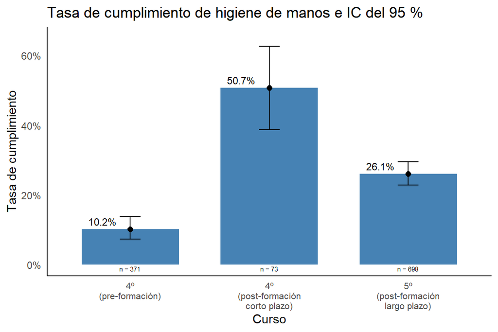

## Por escenario y curso

**Tip**

El escenario de Consulta es el único con trazabilidad del efecto en todos los cursos.  
El escenario de Procedimiento Invasivo solo está en el último curso (post-largo): representa más d eun tercio de las oportunidades de higiene de manos y su tasa de cumplimiento es del 46 %

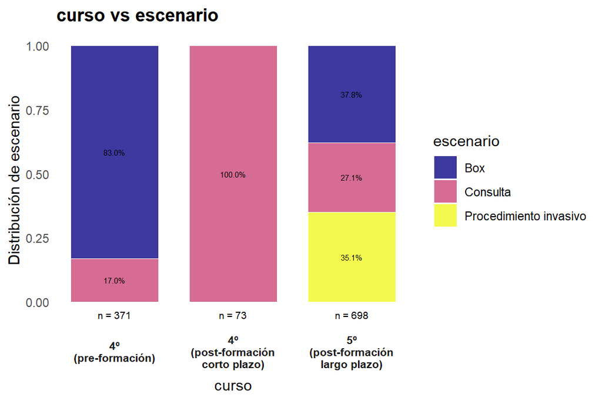

Tasas de cumplimiento por tipo de escenario e IC del 95 %

|  | Tasa de cumplimiento | IC 95 % inf | IC 95 % sup |
| --- | --- | --- | --- |
| Box | 0.038 | 0.024 | 0.058 |
| Consulta | 0.375 | 0.323 | 0.431 |
| Procedimiento invasivo | 0.461 | 0.398 | 0.526 |

Comparamos la tasa de cumplimiento por escenario: calculamos la diferencia de proporciones y obtenemos el p-valor ajustado por Bonferroni.

Test de proporciones entre las tasas de cumplimiento

| Grupo 1 | Grupo 2 | n 1 | n 2 | Tasa cumplimiento 1 | Tasa cumplimiento 2 | Diferencia | p valor |
| --- | --- | --- | --- | --- | --- | --- | --- |
| Box | Consulta | 572 | 325 | 0.038 | 0.375 | -0.337 | <0.001 |
| Box | Procedimiento invasivo | 572 | 245 | 0.038 | 0.461 | -0.423 | <0.001 |
| Consulta | Procedimiento invasivo | 325 | 245 | 0.375 | 0.461 | -0.086 | 0.145 |

**Box**

Tasas de cumplimiento en el escenario BOX con IC del 95%

[output not shown]

Calculamos la diferencia de la tasa de cumplimiento y obtenemos el p-valor ajustado por Bonferroni.

Test de proporciones entre las tasas de cumplimiento en el escenario BOX

| Grupo 1 | Grupo 2 | n 1 | n 2 | Tasa cumplimiento 1 | Tasa cumplimiento 2 | Diferencia | p valor |
| --- | --- | --- | --- | --- | --- | --- | --- |
| 4º (pre-formación) | 5º (post-formación largo plazo) | 308 | 264 | 0.045 | 0.03 | 0.015 | 0.471 |

[figure not shown]

**Consulta**

Tasas de cumplimiento en el escenario Consulta con IC del 95%

[output not shown]

Calculamos la diferencia de la tasa de cumplimiento y obtenemos el p-valor ajustado por Bonferroni.

Test de proporciones en el escenario Consulta entre las tasas de cumplimiento

| Grupo 1 | Grupo 2 | n 1 | n 2 | Tasa cumplimiento 1 | Tasa cumplimiento 2 | Diferencia | p valor |
| --- | --- | --- | --- | --- | --- | --- | --- |
| 4º (pre-formación) | 4º (post-formación corto plazo) | 63 | 73 | 0.381 | 0.507 | -0.126 | 0.582 |
| 4º (pre-formación) | 5º (post-formación largo plazo) | 63 | 189 | 0.381 | 0.323 | 0.058 | 1.000 |
| 4º (post-formación corto plazo) | 5º (post-formación largo plazo) | 73 | 189 | 0.507 | 0.323 | 0.184 | <0.05 |

[figure not shown]

**Important**

Se vuelve a comparar la tasa de cumplimiento de la HM entre cursos **sin** el escenario de procedimiento invasivo.

Tasas de cumplimiento con IC del 95%

|  | Tasa de cumplimiento | IC 95 % inf | IC 95 % sup |
| --- | --- | --- | --- |
| 4º (pre-formación) | 0.102 | 0.074 | 0.138 |
| 4º (post-formación corto plazo) | 0.507 | 0.387 | 0.626 |
| 5º (post-formación largo plazo) | 0.152 | 0.120 | 0.189 |

Comparamos la tasa de cumplimiento por curso: calculamos la diferencia de proporciones y obtenemos el p-valor ajustado por Bonferroni.

Test de proporciones entre las tasas de cumplimiento (sin el escenario de procedimiento invasivo)

| Grupo 1 | Grupo 2 | n 1 | n 2 | Tasa cumplimiento 1 | Tasa cumplimiento 2 | Diferencia | p valor |
| --- | --- | --- | --- | --- | --- | --- | --- |
| 4º (pre-formación) | 4º (post-formación corto plazo) | 371 | 73 | 0.102 | 0.507 | -0.404 | <0.001 |
| 4º (pre-formación) | 5º (post-formación largo plazo) | 371 | 453 | 0.102 | 0.152 | -0.050 | 0.132 |
| 4º (post-formación corto plazo) | 5º (post-formación largo plazo) | 73 | 453 | 0.507 | 0.152 | 0.355 | <0.001 |

**Tip**

El aumento del cumplimiento de la higiene de manos entre pre y post-corto sigue siendo significativo.  
La diferencia entre post-corto y post-largo sigue siendo significativa, lo que sugiere que el efecto de la formación se disipa.  
PERO el cambio entre pre y post-largo no es significativo para una confianza del 95 %, por lo que la formación tiene **no tiene efecto** a largo plazo en la adherencia a la higiene de manos si no contamos con el escanario de procedimiento invasivo.

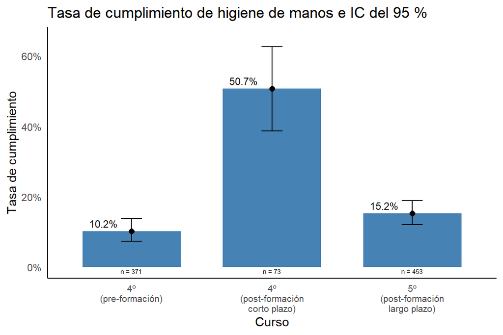

## Por momento OMS

Tasas de cumplimiento por tipo de indicacion e IC del 95 %

|  | Tasa de cumplimiento | IC 95 % inf | IC 95 % sup |
| --- | --- | --- | --- |
| M1 | 0.237 | 0.200 | 0.278 |
| M2 | 0.706 | 0.622 | 0.781 |
| M3 | 0.109 | 0.062 | 0.173 |
| M4 | 0.090 | 0.062 | 0.125 |
| M5 | 0.049 | 0.006 | 0.165 |

Comparamos la tasa de cumplimiento por escenario: calculamos la diferencia de proporciones y obtenemos el p-valor ajustado por Bonferroni.

Test de proporciones entre las tasas de cumplimiento

| Grupo 1 | Grupo 2 | n 1 | n 2 | Tasa cumplimiento 1 | Tasa cumplimiento 2 | Diferencia | p valor |
| --- | --- | --- | --- | --- | --- | --- | --- |
| M1 | M2 | 472 | 136 | 0.237 | 0.706 | -0.469 | <0.001 |
| M1 | M3 | 472 | 138 | 0.237 | 0.109 | 0.129 | <0.05 |
| M1 | M4 | 472 | 355 | 0.237 | 0.090 | 0.147 | <0.001 |
| M1 | M5 | 472 | 41 | 0.237 | 0.049 | 0.189 | <0.1 |
| M2 | M3 | 136 | 138 | 0.706 | 0.109 | 0.597 | <0.001 |
| M2 | M4 | 136 | 355 | 0.706 | 0.090 | 0.616 | <0.001 |
| M2 | M5 | 136 | 41 | 0.706 | 0.049 | 0.657 | <0.001 |
| M3 | M4 | 138 | 355 | 0.109 | 0.090 | 0.019 | 1.000 |
| M3 | M5 | 138 | 41 | 0.109 | 0.049 | 0.060 | 1.000 |
| M4 | M5 | 355 | 41 | 0.090 | 0.049 | 0.041 | 1.000 |

# Momentos de la OMS

- Para cada indicación (momento OMS) de higiene de manos se muestra:
  - Número de oportunidades total.
  - Número de oportunidades por curso.
  - Número de oportunidades cumplidas por curso.
  - Tasa de cumplimiento por curso.
- Las tasas de cumplimiento entre los cursos se comparan mediante pruebas no paramétricas de independencia: Chi-cuadrado o test exacto de Fisher.
- La hipótesis nula establece que la distribución del cumplimiento de la higiene de manos es igual en todos los cursos, es decir, no hay relación entre el curso y cumplir con la higiene de manos.
- Un p-valor bajo indica evidencia suficiente para rechazar la hipótesis nula: al menos un curso tiene una tasa de cumplimiento diferente a los demás.

En los casos donde el p-valor es bajo, se realizan comparaciones **dos a dos** entre cursos para identificar qué pares de cursos son significativamente diferentes.

**M1**

```
Momento de Higiene de manos M1 (472 oportunidades).
```

| **Characteristic** | **N** | **4º (pre-formación)** N = 173<sup>1</sup> | **4º (post-formación corto plazo)** N = 33<sup>1</sup> | **5º (post-formación largo plazo)** N = 266<sup>1</sup> | **p-value**<sup>2</sup> |
| --- | --- | --- | --- | --- | --- |
| accion | 472 | 29 (16.8%) | 24 (72.7%) | 59 (22.2%) | <0.001 |

<sup>1</sup> n (%)  
<sup>2</sup> Pearson’s Chi-squared test

Tasas de cumplimiento en el momento OMS M1 con IC del 95%

|  | Tasa de cumplimiento | IC 95 % inf | IC 95 % sup |
| --- | --- | --- | --- |
| 4º (pre-formación) | 0.168 | 0.115 | 0.232 |
| 4º (post-formación corto plazo) | 0.727 | 0.545 | 0.867 |
| 5º (post-formación largo plazo) | 0.222 | 0.173 | 0.277 |

Calculamos la diferencia de la tasa de cumplimiento y obtenemos el p-valor ajustado por Bonferroni.

Test de proporciones entre las tasas de cumplimiento en el momento OMS M1

| Grupo 1 | Grupo 2 | n 1 | n 2 | Tasa cumplimiento 1 | Tasa cumplimiento 2 | Diferencia | p valor |
| --- | --- | --- | --- | --- | --- | --- | --- |
| 4º (pre-formación) | 4º (post-formación corto plazo) | 173 | 33 | 0.168 | 0.727 | -0.560 | <0.001 |
| 4º (pre-formación) | 5º (post-formación largo plazo) | 173 | 266 | 0.168 | 0.222 | -0.054 | 0.619 |
| 4º (post-formación corto plazo) | 5º (post-formación largo plazo) | 33 | 266 | 0.727 | 0.222 | 0.505 | <0.001 |

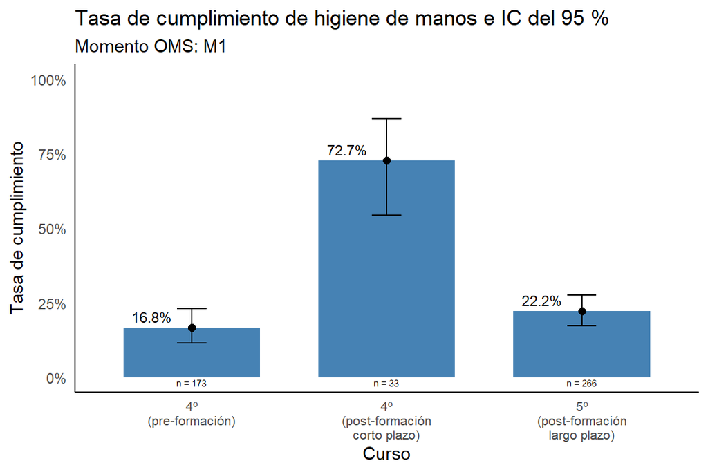

**M2**

```
Momento de Higiene de manos M2 (136 oportunidades).
```

| **Characteristic** | **N** | **4º (pre-formación)** N = 5<sup>1</sup> | **4º (post-formación corto plazo)** N = 0<sup>1</sup> | **5º (post-formación largo plazo)** N = 131<sup>1</sup> | **p-value**<sup>2</sup> |
| --- | --- | --- | --- | --- | --- |
| accion | 136 | 0 (0.0%) | 0 (NA%) | 96 (73.3%) | 0.002 |

<sup>1</sup> n (%)  
<sup>2</sup> Fisher’s exact test

Tasas de cumplimiento en el momento OMS M2 con IC del 95%

|  | Tasa de cumplimiento | IC 95 % inf | IC 95 % sup |
| --- | --- | --- | --- |
| 4º (pre-formación) | 0.000 | 0.000 | 0.522 |
| 5º (post-formación largo plazo) | 0.733 | 0.648 | 0.806 |

Calculamos la diferencia de la tasa de cumplimiento y obtenemos el p-valor ajustado por Bonferroni.

Test de proporciones entre las tasas de cumplimiento en el momento OMS M2

| Grupo 1 | Grupo 2 | n 1 | n 2 | Tasa cumplimiento 1 | Tasa cumplimiento 2 | Diferencia | p valor |
| --- | --- | --- | --- | --- | --- | --- | --- |
| 4º (pre-formación) | 5º (post-formación largo plazo) | 5 | 131 | 0 | 0.733 | -0.733 | <0.01 |

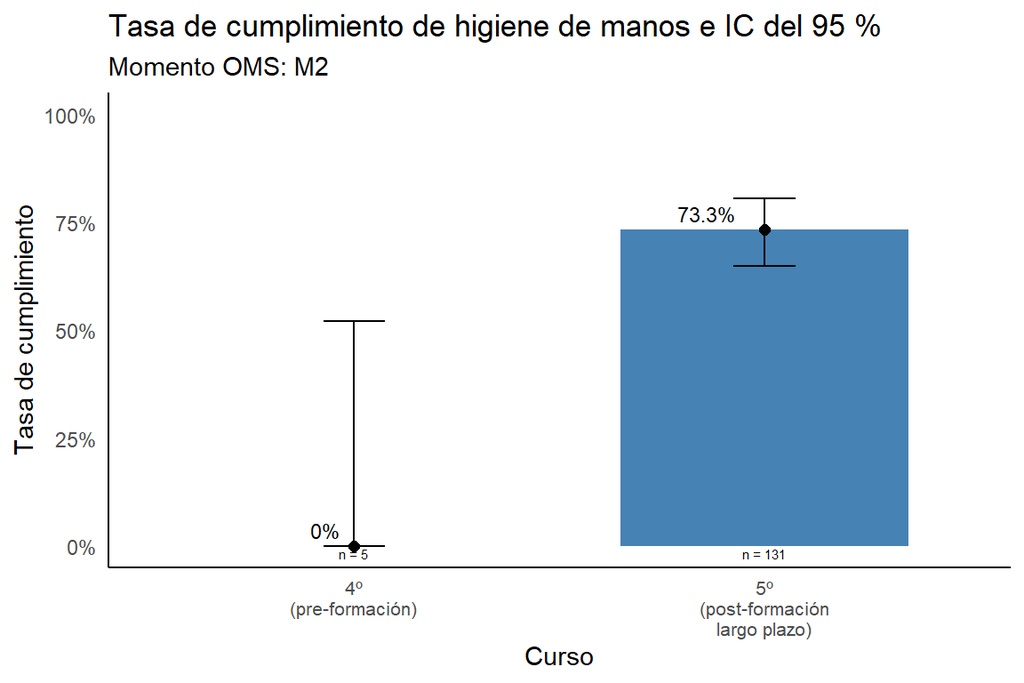

**M3**

```
Momento de Higiene de manos M3 (138 oportunidades).
```

| **Characteristic** | **N** | **4º (pre-formación)** N = 9<sup>1</sup> | **4º (post-formación corto plazo)** N = 0<sup>1</sup> | **5º (post-formación largo plazo)** N = 129<sup>1</sup> | **p-value**<sup>2</sup> |
| --- | --- | --- | --- | --- | --- |
| accion | 138 | 0 (0.0%) | 0 (NA%) | 15 (11.6%) | 0.6 |

<sup>1</sup> n (%)  
<sup>2</sup> Fisher’s exact test

**M4**

```
Momento de Higiene de manos M4 (355 oportunidades).
```

| **Characteristic** | **N** | **4º (pre-formación)** N = 158<sup>1</sup> | **4º (post-formación corto plazo)** N = 40<sup>1</sup> | **5º (post-formación largo plazo)** N = 157<sup>1</sup> | **p-value**<sup>2</sup> |
| --- | --- | --- | --- | --- | --- |
| accion | 355 | 8 (5.1%) | 13 (32.5%) | 11 (7.0%) | <0.001 |

<sup>1</sup> n (%)  
<sup>2</sup> Fisher’s exact test

Tasas de cumplimiento en el momento OMS M4 con IC del 95%

|  | Tasa de cumplimiento | IC 95 % inf | IC 95 % sup |
| --- | --- | --- | --- |
| 4º (pre-formación) | 0.051 | 0.022 | 0.097 |
| 4º (post-formación corto plazo) | 0.325 | 0.186 | 0.491 |
| 5º (post-formación largo plazo) | 0.070 | 0.035 | 0.122 |

Calculamos la diferencia de la tasa de cumplimiento y obtenemos el p-valor ajustado por Bonferroni.

Test de proporciones entre las tasas de cumplimiento en el momento OMS M4

| Grupo 1 | Grupo 2 | n 1 | n 2 | Tasa cumplimiento 1 | Tasa cumplimiento 2 | Diferencia | p valor |
| --- | --- | --- | --- | --- | --- | --- | --- |
| 4º (pre-formación) | 4º (post-formación corto plazo) | 158 | 40 | 0.051 | 0.325 | -0.274 | <0.001 |
| 4º (pre-formación) | 5º (post-formación largo plazo) | 158 | 157 | 0.051 | 0.070 | -0.019 | 1.000 |
| 4º (post-formación corto plazo) | 5º (post-formación largo plazo) | 40 | 157 | 0.325 | 0.070 | 0.255 | <0.001 |

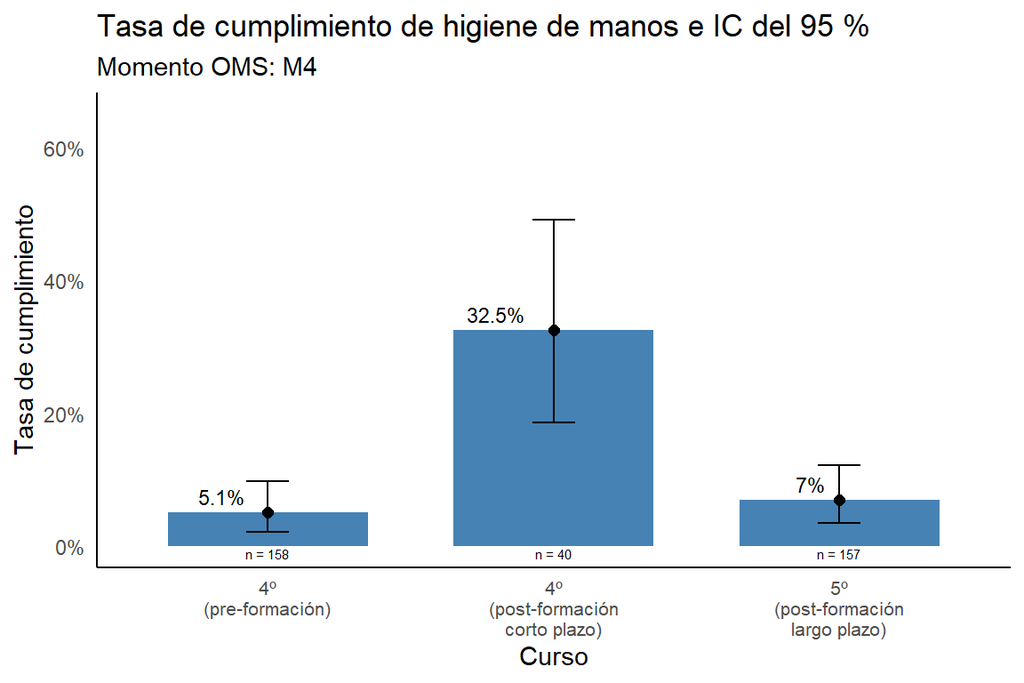

**M5**

```
Momento de Higiene de manos M5 (41 oportunidades).
```

| **Characteristic** | **N** | **4º (pre-formación)** N = 26<sup>1</sup> | **4º (post-formación corto plazo)** N = 0<sup>1</sup> | **5º (post-formación largo plazo)** N = 15<sup>1</sup> | **p-value**<sup>2</sup> |
| --- | --- | --- | --- | --- | --- |
| accion | 41 | 1 (3.8%) | 0 (NA%) | 1 (6.7%) | >0.9 |

<sup>1</sup> n (%)  
<sup>2</sup> Fisher’s exact test

# Modelos

El objetivo es medir el efecto del curso, la indicación y el escenario sobre la higiene de manos.  
**Se considera el curso como ORDINAL para cuantificar el efecto tiempo**, ya que suponemos que no están igualmente espaciados (en ese caso se incluiría en los modelos como numérica).

| Resultado | Qué afirmar |
| --- | --- |
| L ✔️ / Q ✔️ | Tendencia + curvatura |
| L ✔️ / Q ❌ | Tendencia lineal |
| L ❌ / Q ✔️ | Efecto no monótono |
| L ❌ / Q ❌ | Sin asociación detectable |

**Interpretación de la variable curso**

Parámetros lineal y cuadrático del factor curso significativos: existe una tendencia global a lo largo de los niveles PERO esa tendencia no es puramente lineal.  
- El efecto del ordinal no puede resumirse en un único “por nivel”.  
- Los cambios entre niveles no son constantes.  
- El nivel intermedio se comporta de forma distinta a lo esperado por una recta.

Modelo con variables independientes: curso, indicación y escenario.

| **Characteristic** | **log(OR)** | **95% CI** | **p-value** |
| --- | --- | --- | --- |
| curso |  |  |  |
| curso.L | -0.41 | -0.77, -0.04 | 0.030 |
| curso.Q | -0.77 | -1.3, -0.29 | 0.002 |
| indicacion |  |  |  |
| M1 | — | — |  |
| M2 | 1.6 | 0.86, 2.3 | <0.001 |
| M3 | -1.7 | -2.5, -0.82 | <0.001 |
| M4 | -1.4 | -1.9, -0.91 | <0.001 |
| M5 | -0.09 | -2.0, 1.2 | >0.9 |
| escenario |  |  |  |
| Box | — | — |  |
| Consulta | 2.8 | 2.3, 3.4 | <0.001 |
| Procedimiento invasivo | 3.0 | 2.3, 3.9 | <0.001 |

Abbreviations: CI = Confidence Interval, OR = Odds Ratio

**Test para confirmar la no linealidad de la variable curso**

El LRT se basa en la idea de que el modelo más restringido es un caso especial del modelo más general.  
El modelo con la varible ordinal tiene dos parámetros para la variable curso, mientras que el modelo con la variable numérica tiene un único parámetro.  
El modelo numérico es más restringido ya que asume una relación lineal entre niveles (restricción fuerte) y el modelo ordinal es menos restringido ya que permite diferencias arbitrarias entre niveles al tener más parámetros (cada factor su propio efecto, menos restringido).  
Nuestro contraste LRT evalúa si la restricción de linealidad es plausible: si no hay diferencia en la verosimilitud, el modelo más simple (variable numérica) puede ser suficiente.

```
H0: el efecto de curso es lineal (modelo numérico es suficiente).
H1: el efecto no es lineal (modelo categórico ajusta mejor).
```

Prueba de razón de verosimilitud (LRT) para evaluar la linealidad del efecto de curso

| term | df.residual | residual.deviance | df | deviance | p valor |
| --- | --- | --- | --- | --- | --- |
| accion ~ as.numeric(curso) + indicacion + escenario | 1134 | 800.8306 | NA | NA | NA |
| accion ~ factor(curso) + indicacion + escenario | 1133 | 790.7713 | 1 | 10.05932 | <0.01 |

```
Se rechaza H0 (p < 0.05): el efecto de curso no es lineal y conviene tratarlo como factor.
```

```
Visualización del patrón no lineal.
```

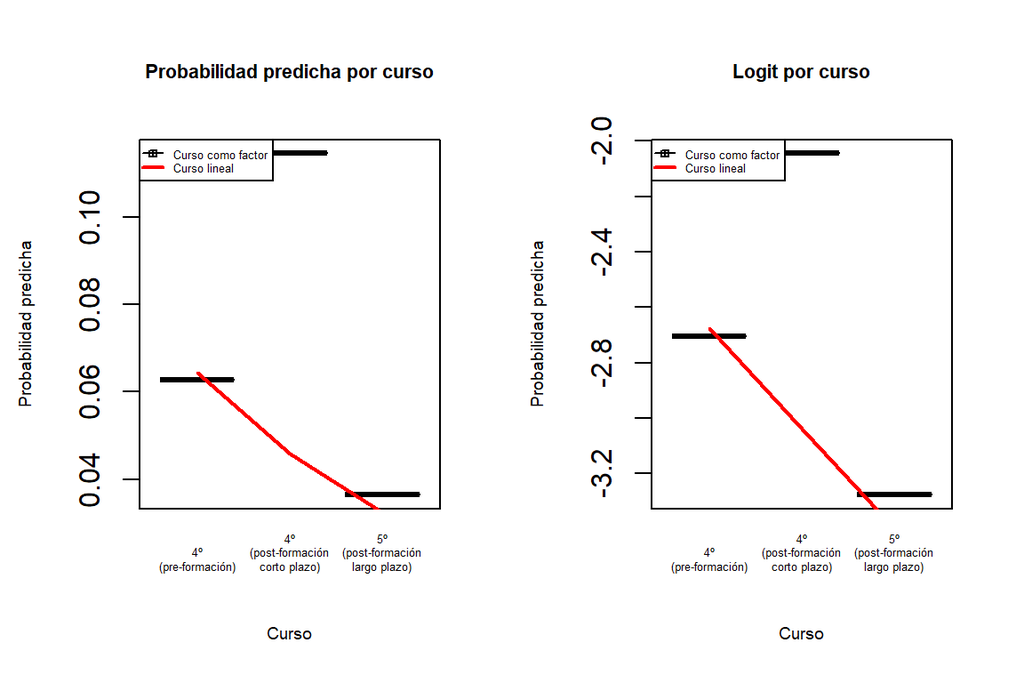

**Conclusiones sobre el efecto de la variable curso**

- Los parámetros lineal y cuadrático del factor curso son significativo.
- El test LRT rechaza la hipótesis nula.
- La relación entre curso y la probabilidad predicha presenta diferencias por curso.

Hay evidencia de una relación no lineal entre el curso y la tasa de cumplimiento de higiene de manos.  
Por ello, **no es apropiado usar odd ratios como medidas de interpretación del efecto del curso**, se recomiendo usar las medias marginales estimadas: *“¿Cuál es el riesgo en cada nivel específico del curso y cómo difieren entre sí?”*

Medias marginales estimadas (probabilidad)

| curso | prob | SE | df | asymp.LCL | asymp.UCL |
| --- | --- | --- | --- | --- | --- |
| 4º (pre-formación) | 0.2592021 | 0.0475527 | Inf | 0.1771898 | 0.3624524 |
| 4º (post-formación corto plazo) | 0.4033476 | 0.0762740 | Inf | 0.2664469 | 0.5571622 |
| 5º (post-formación largo plazo) | 0.1647415 | 0.0263755 | Inf | 0.1193028 | 0.2231023 |

Comparaciones pareadas entre niveles de curso usando estimaciones marginales

| contrast | estimate | SE | df | z.ratio | p valor |
| --- | --- | --- | --- | --- | --- |
| (4º (pre-formación)) - (4º (post-formación corto plazo)) | -0.6585838 | 0.3496758 | Inf | -1.883412 | 0.143 |
| (4º (pre-formación)) - (5º (post-formación largo plazo)) | 0.5732440 | 0.2645314 | Inf | 2.167016 | <0.1 |
| (4º (post-formación corto plazo)) - (5º (post-formación largo plazo)) | 1.2318277 | 0.3077471 | Inf | 4.002727 | <0.001 |

Interpretación: si estimate > 0, el primer grupo tiene mayor media; si estimate < 0, el segundo grupo tiene mayor media.  
- **pre vs post-corto**. Diferencia negativa (post-corto > pre): la tasa aumenta a corto plazo pero no es significativo.  
- **pre vs post-largo**. Diferencia positiva (post-largo < pre): la tasa disminuye a largo plazo pero no es significativo.  
- **post-corto vs post-largo**. Diferencia positiva (post-largo < post-corto), la tasa disminuye con el tiempo en los cursos post-formación y la disminución sí es significativa.

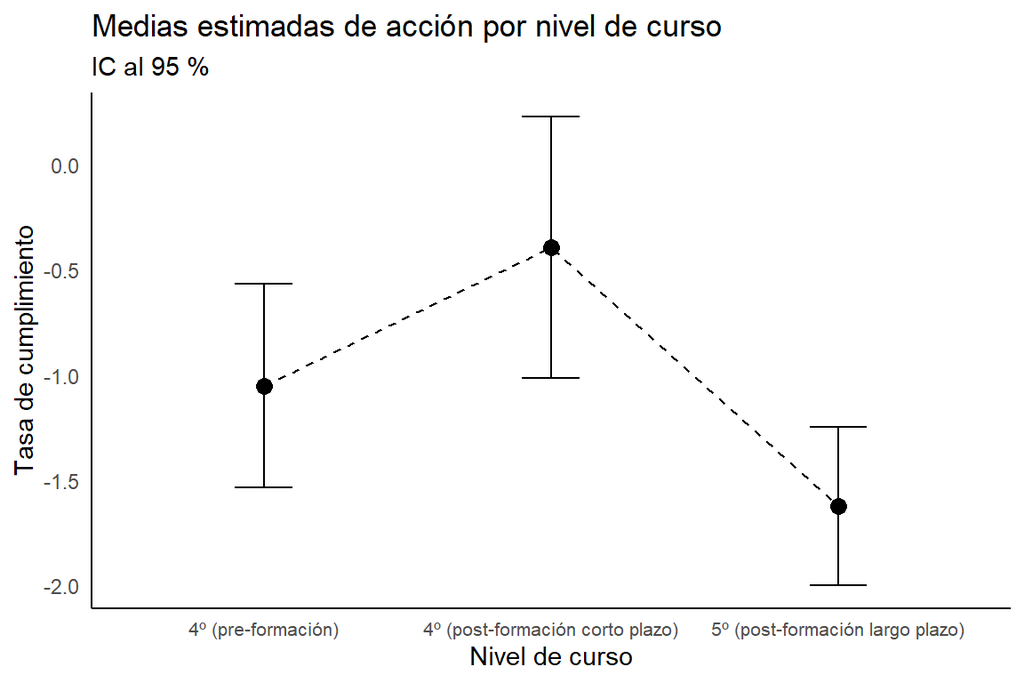

**Escenario Consulta**

Se repetir el modelo usando solo el escenario de Consulta.

```
H0: el efecto de curso es lineal (modelo numérico es suficiente).
H1: el efecto no es lineal (modelo categórico ajusta mejor).
```

Prueba de razón de verosimilitud (LRT) para evaluar la linealidad del efecto de curso

| term | df.residual | residual.deviance | df | deviance | p valor |
| --- | --- | --- | --- | --- | --- |
| accion ~ as.numeric(curso) + indicacion | 320 | 391.9817 | NA | NA | NA |
| accion ~ factor(curso) + indicacion | 319 | 380.2034 | 1 | 11.77831 | <0.001 |

```
Se rechaza H0 (p < 0.05): el efecto de curso no es lineal y conviene tratarlo como factor.
```

```
Visualización del patrón no lineal.
```

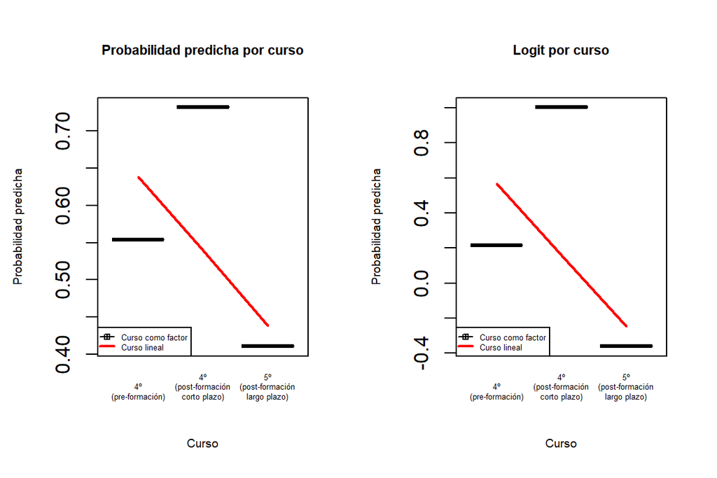

**Note**

Hay evidencia de una relación no lineal entre el curso y la tasa de cumplimiento de higiene de manos.  
Por ello, **no es apropiado usar odd ratios como medidas de interpretación del efecto del curso**, se recomiendo usar las medias marginales estimadas: *“¿Cuál es el riesgo en cada nivel específico del curso y cómo difieren entre sí?”*

Medias marginales estimadas (probabilidad)

| curso | prob | SE | df | asymp.LCL | asymp.UCL |
| --- | --- | --- | --- | --- | --- |
| 4º (pre-formación) | 0.4650606 | 0.1234428 | Inf | 0.2474034 | 0.6968911 |
| 4º (post-formación corto plazo) | 0.6560655 | 0.1160066 | Inf | 0.4105151 | 0.8393575 |
| 5º (post-formación largo plazo) | 0.3280542 | 0.1004945 | Inf | 0.1665148 | 0.5440192 |

Comparaciones pareadas entre niveles de curso usando estimaciones marginales

| contrast | estimate | SE | df | z.ratio | p valor |
| --- | --- | --- | --- | --- | --- |
| (4º (pre-formación)) - (4º (post-formación corto plazo)) | -0.7857955 | 0.3896175 | Inf | -2.016838 | 0.108 |
| (4º (pre-formación)) - (5º (post-formación largo plazo)) | 0.5770131 | 0.3323323 | Inf | 1.736254 | 0.192 |
| (4º (post-formación corto plazo)) - (5º (post-formación largo plazo)) | 1.3628085 | 0.3303295 | Inf | 4.125603 | <0.001 |

Interpretación: si estimate > 0, el primer grupo tiene mayor media; si estimate < 0, el segundo grupo tiene mayor media.  
- **pre vs post-corto**. Diferencia negativa (post-corto > pre): la tasa aumenta a corto plazo pero no es significativo.  
- **pre vs post-largo**. Diferencia positiva (post-largo < pre): la tasa disminuye a largo plazo pero no es significativo.  
- **post-corto vs post-largo**. Diferencia positiva (post-largo < post-corto), la tasa disminuye con el tiempo en los cursos post-formación y la disminución sí es significativa.

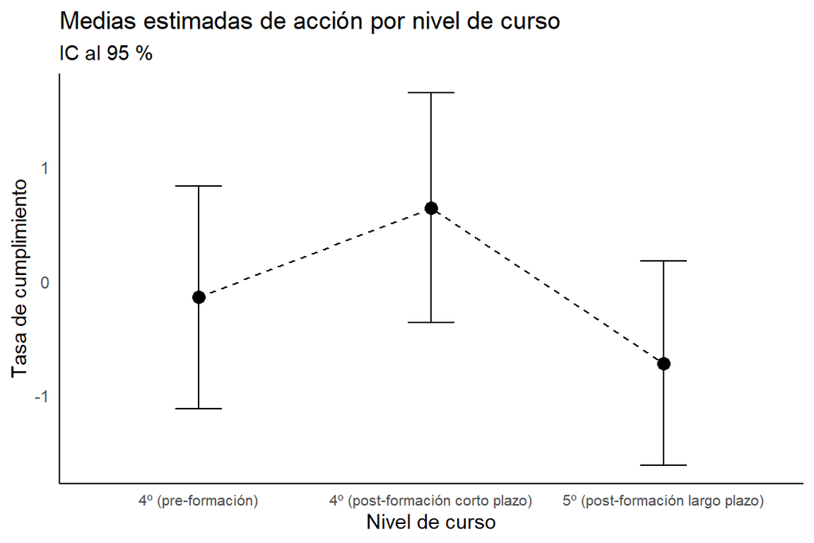